# Biostat 203B Homework 3

Due Feb 23 @ 11:59PM

Author

Zehan Hu 306329221

Load necessary libraries (you can add more as needed).

```r
library(arrow)
library(gtsummary)
library(memuse)
library(pryr)
library(R.utils)
library(tidyverse)
library(dplyr)
```

Display your machine memory.

```r
rm(list = ls())
```

```r
memuse::Sys.meminfo()
```

```
Totalram:  7.634 GiB
Freeram:   6.360 GiB
```

In this exercise, we use tidyverse (ggplot2, dplyr, etc) to explore the [MIMIC-IV](https://mimic.mit.edu/docs/iv/) data introduced in [homework 1](https://ucla-biostat-203b.github.io/2024winter/hw/hw1/hw1.html) and to build a cohort of ICU stays.

## Q1. Visualizing patient trajectory

Visualizing a patient’s encounters in a health care system is a common task in clinical data analysis. In this question, we will visualize a patient’s ADT (admission-discharge-transfer) history and ICU vitals in the MIMIC-IV data.

### Q1.1 ADT history

A patient’s ADT history records the time of admission, discharge, and transfer in the hospital. This figure shows the ADT history of the patient with `subject_id` 10001217 in the MIMIC-IV data. The x-axis is the calendar time, and the y-axis is the type of event (ADT, lab, procedure). The color of the line segment represents the care unit. The size of the line segment represents whether the care unit is an ICU/CCU. The crosses represent lab events, and the shape of the dots represents the type of procedure. The title of the figure shows the patient’s demographic information and the subtitle shows top 3 diagnoses.

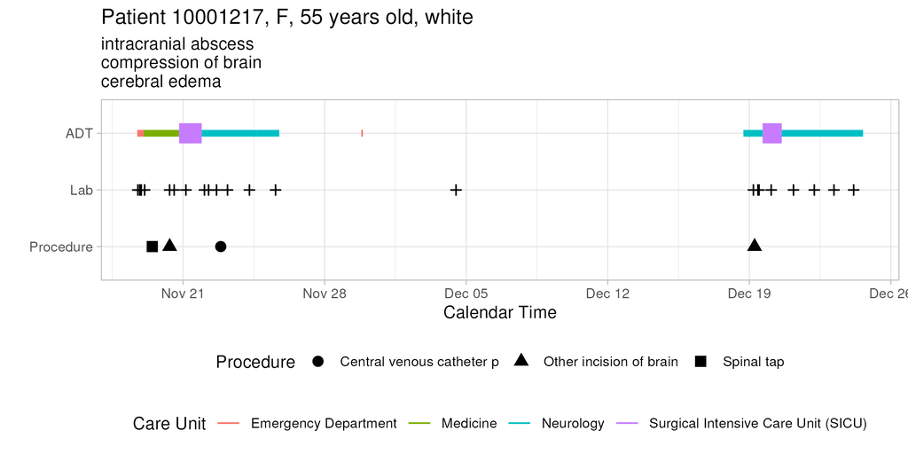

Do a similar visualization for the patient with `subject_id` 10013310 using ggplot.

Hint: We need to pull information from data files `patients.csv.gz`, `admissions.csv.gz`, `transfers.csv.gz`, `labevents.csv.gz`, `procedures_icd.csv.gz`, `diagnoses_icd.csv.gz`, `d_icd_procedures.csv.gz`, and `d_icd_diagnoses.csv.gz`. For the big file `labevents.csv.gz`, use the Parquet format you generated in Homework 2. For reproducibility, make the Parquet folder `labevents_pq` available at the current working directory `hw3`, for example, by a symbolic link. Make your code reproducible.

```bash
ls -l ~/mimic/
```

```
total 24
-rwxrwxrwx 1 eewol123 eewol123 13332 Jan 26 00:42 CHANGELOG.txt
-rwxrwxrwx 1 eewol123 eewol123  2518 Jan 26 00:42 LICENSE.txt
-rwxrwxrwx 1 eewol123 eewol123  2884 Jan 26 00:42 SHA256SUMS.txt
drwxrwxrwx 1 eewol123 eewol123  4096 Feb 29 17:18 hosp
drwxrwxrwx 1 eewol123 eewol123  4096 Feb 29 17:20 icu
```

read in diagnoses_icd.csv.gz and d_icd_diagnoses.csv.gz

```r
patient_id <- 10013310

diagnoses<- read_csv("~/mimic/hosp/diagnoses_icd.csv.gz",
                     show_col_types = FALSE
                     )%>%
  filter(subject_id == patient_id)%>%
  left_join(
    read_csv("~/mimic/hosp/d_icd_diagnoses.csv.gz",
             show_col_types = FALSE
    ),by=c("icd_code","icd_version")
  )
```

```r
procedures<- read_csv("~/mimic/hosp/procedures_icd.csv.gz",
                     show_col_types = FALSE
                     )%>%
  filter(subject_id == patient_id)%>%
  left_join(
    read_csv("~/mimic/hosp/d_icd_procedures.csv.gz",
             show_col_types = FALSE
    ),by=c("icd_code","icd_version")
  )
```

```r
admissions<-read_csv("~/mimic/hosp/admissions.csv.gz",
                     show_col_types = FALSE
                     )%>%
  filter(subject_id == patient_id)
```

```r
transfers<-read_csv("~/mimic/hosp/transfers.csv.gz",
                     show_col_types = FALSE
                     )%>%
  filter(subject_id == patient_id)
```

```r
patients<-read_csv("~/mimic/hosp/patients.csv.gz",
                     show_col_types = FALSE
                     )%>%
  filter(subject_id == patient_id)
```

```bash
ls -l ~/mimic/hosp/
```

```
total 20248088
-rwxrwxrwx 1 eewol123 eewol123    15516088 Jan 26 00:42 admissions.csv.gz
-rwxrwxrwx 1 eewol123 eewol123  2467761053 Jan 25 21:45 chartevents.csv.gz
-rwxrwxrwx 1 eewol123 eewol123      427468 Jan 26 00:42 d_hcpcs.csv.gz
-rwxrwxrwx 1 eewol123 eewol123      859438 Jan 26 00:42 d_icd_diagnoses.csv.gz
-rwxrwxrwx 1 eewol123 eewol123      578517 Jan 26 00:42 d_icd_procedures.csv.gz
-rwxrwxrwx 1 eewol123 eewol123       12900 Jan 26 00:42 d_labitems.csv.gz
-rwxrwxrwx 1 eewol123 eewol123    25070720 Jan 26 00:42 diagnoses_icd.csv.gz
-rwxrwxrwx 1 eewol123 eewol123     7426955 Jan 26 00:42 drgcodes.csv.gz
-rwxrwxrwx 1 eewol123 eewol123   508524623 Jan 26 00:42 emar.csv.gz
-rwxrwxrwx 1 eewol123 eewol123   471096030 Jan 26 00:42 emar_detail.csv.gz
-rwxrwxrwx 1 eewol123 eewol123     1767138 Jan 26 00:42 hcpcsevents.csv.gz
-rwxrwxrwx 1 eewol123 eewol123 13730083993 Jan 26 00:42 labevents.csv
-rwxrwxrwx 1 eewol123 eewol123  1939088924 Jan 25 21:45 labevents.csv.gz
-rwxrwxrwx 1 eewol123 eewol123    96698496 Jan 26 00:42 microbiologyevents.csv.gz
-rwxrwxrwx 1 eewol123 eewol123    36124944 Jan 26 00:42 omr.csv.gz
-rwxrwxrwx 1 eewol123 eewol123     2312631 Jan 26 00:42 patients.csv.gz
-rwxrwxrwx 1 eewol123 eewol123   398753125 Jan 26 00:42 pharmacy.csv.gz
-rwxrwxrwx 1 eewol123 eewol123   498505135 Jan 26 00:42 poe.csv.gz
-rwxrwxrwx 1 eewol123 eewol123    25477219 Jan 26 00:42 poe_detail.csv.gz
-rwxrwxrwx 1 eewol123 eewol123   458817415 Jan 26 00:43 prescriptions.csv.gz
-rwxrwxrwx 1 eewol123 eewol123     6027067 Jan 26 00:43 procedures_icd.csv.gz
-rwxrwxrwx 1 eewol123 eewol123      122507 Jan 26 00:43 provider.csv.gz
-rwxrwxrwx 1 eewol123 eewol123     6781247 Jan 26 00:43 services.csv.gz
-rwxrwxrwx 1 eewol123 eewol123    36158338 Jan 26 00:43 transfers.csv.gz
```

```r
library(tidyverse)
library(arrow)

csv_file_path_lab <- "~/mimic/hosp/labevents.csv"
parquet_file_lab <- "./labevents.parquet"
```

```r
# Read the CSV file
labevents_dataset <- arrow::open_dataset(csv_file_path_lab, format = "csv")

# Write the dataset to a Parquet file
arrow::write_dataset(labevents_dataset, parquet_file_lab, format = "parquet")
```

```r
# Open the Parquet dataset


# Filter the data for subject_id 10013310 without loading everything into memory
labev <- arrow::open_dataset(parquet_file_lab) %>%
  filter(subject_id == patient_id ) %>%
  collect()
```

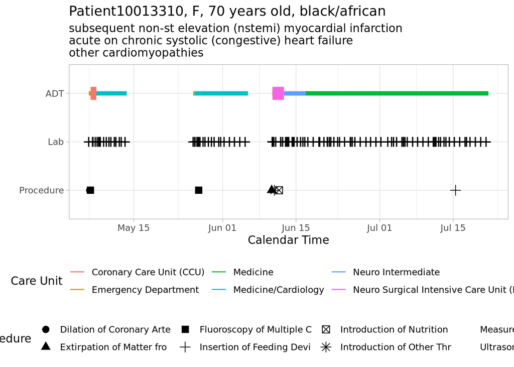

```r
  ggplot () +
      geom_segment(
        data = transfers |> filter(eventtype != "discharge"),
        mapping = aes (
          x = intime,
          xend = outtime,
          y = "ADT",
          yend = "ADT",
          color = careunit,
          linewidth = str_detect(careunit, "(ICU|CCU)")
        ),
      )+

      geom_point (
        data = labev |> distinct(charttime, .keep_all = TRUE),
        mapping = aes(x = charttime, y = "Lab"),
        shape = '+',
        size = 5
      ) +

      geom_jitter(
        # only keep the ist procedure on the same day
        data = procedures,
        mapping = aes (
          x = chartdate + hours (12),
          y = "Procedure",
          shape = str_sub(long_title, 1, 25)),size = 3,height = 0
      ) +

      labs(title = str_c(
        "Patient", patient_id,", ",
        patients$gender, ", ",
        patients$anchor_age+year(admissions$admittime[1])-patients$anchor_year,
        " years old, ",
        str_to_lower(admissions$race[1])
      ),
      subtitle = str_c(str_to_lower(diagnoses$long_title[1:3]), collapse = "\n"),
      x = "Calendar Time",
      y="",
      color = "Care Unit",
      shape = "Procedure"
      ) +
      guides(linewidth = "none") +
      scale_y_discrete(limits = rev) +
      theme_light() +
      theme(legend.position = "bottom", legend.box = "vertical")
```

### Q1.2 ICU stays

ICU stays are a subset of ADT history. This figure shows the vitals of the patient `10001217` during ICU stays. The x-axis is the calendar time, and the y-axis is the value of the vital. The color of the line represents the type of vital. The facet grid shows the abbreviation of the vital and the stay ID.

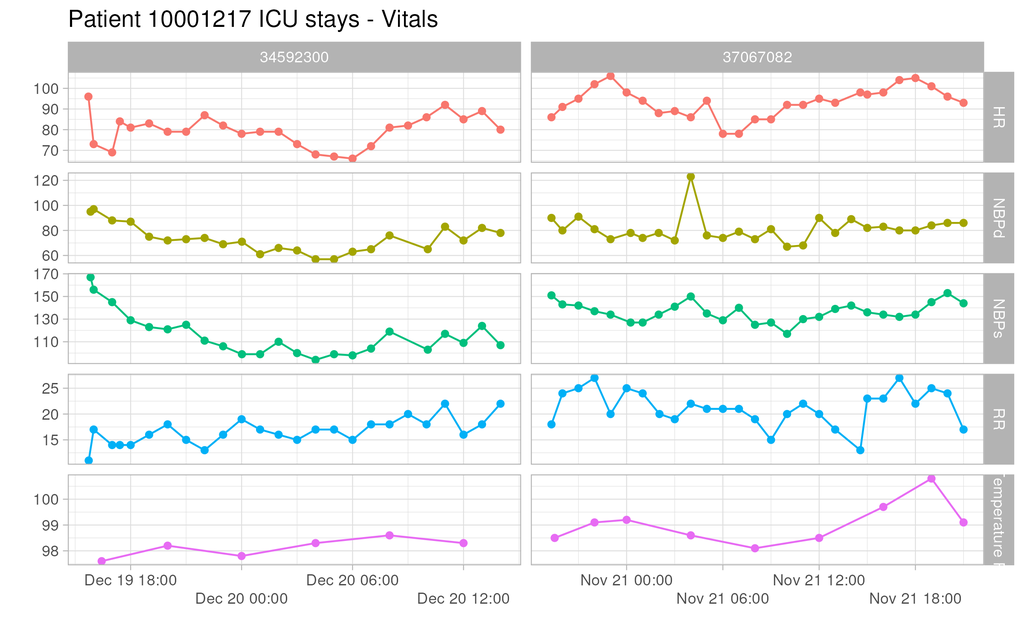

Do a similar visualization for the patient `10013310`.

```r
csv_file_chart <- "~/mimic/icu/chartevents.csv"
parquet_file_chart <- "./chartevents.parquet"
```

```r
# Read the CSV file
chartevents_dataset <- arrow::open_dataset(csv_file_chart, format = "csv")

# Write the dataset to a Parquet file
arrow::write_dataset(chartevents_dataset, parquet_file_chart, format = "parquet")
```

```r
# Filter the data for subject_id 10013310 without loading everything into memory
chartev <- arrow::open_dataset(parquet_file_chart, format = "parquet") %>%
  filter(subject_id == patient_id ) %>%
  collect()
# Use collect() to bring the filtered data into memory as a dataframe
```

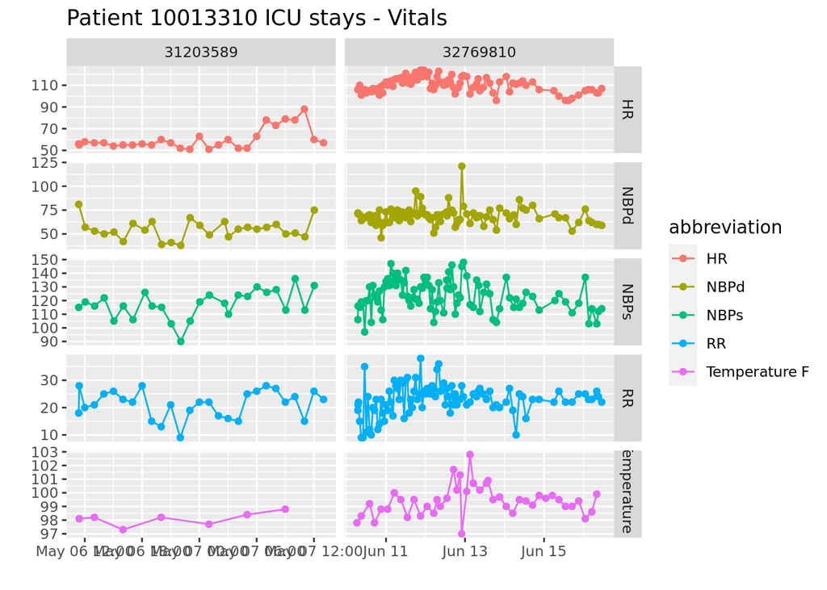

```r
items = read_csv("~/mimic/icu/d_items.csv.gz") %>%
      filter(itemid %in% c(220045, 220179, 220180, 220210, 223761))
    ces = chartev %>%
      filter(subject_id %in% patient_id,
             itemid %in% c(220045, 220179, 220180, 220210, 223761))

    ads = left_join(ces, items)
     ggplot(ads, aes(x = charttime, y = valuenum, color = abbreviation, group = abbreviation)) +
      geom_line() +
      geom_point() +
      facet_grid(abbreviation ~ stay_id, scales = "free") +
      labs(title = str_c("Patient ", patient_id, " ICU stays - Vitals"),
           x = "",
           y = "")
```

## Q2. ICU stays

`icustays.csv.gz` (https://mimic.mit.edu/docs/iv/modules/icu/icustays/) contains data about Intensive Care Units (ICU) stays. The first 10 lines are

```bash
zcat < ~/mimic/icu/icustays.csv.gz | head
```

```
subject_id,hadm_id,stay_id,first_careunit,last_careunit,intime,outtime,los
10000032,29079034,39553978,Medical Intensive Care Unit (MICU),Medical Intensive Care Unit (MICU),2180-07-23 14:00:00,2180-07-23 23:50:47,0.4102662037037037
10000980,26913865,39765666,Medical Intensive Care Unit (MICU),Medical Intensive Care Unit (MICU),2189-06-27 08:42:00,2189-06-27 20:38:27,0.4975347222222222
10001217,24597018,37067082,Surgical Intensive Care Unit (SICU),Surgical Intensive Care Unit (SICU),2157-11-20 19:18:02,2157-11-21 22:08:00,1.1180324074074075
10001217,27703517,34592300,Surgical Intensive Care Unit (SICU),Surgical Intensive Care Unit (SICU),2157-12-19 15:42:24,2157-12-20 14:27:41,0.9481134259259258
10001725,25563031,31205490,Medical/Surgical Intensive Care Unit (MICU/SICU),Medical/Surgical Intensive Care Unit (MICU/SICU),2110-04-11 15:52:22,2110-04-12 23:59:56,1.338587962962963
10001884,26184834,37510196,Medical Intensive Care Unit (MICU),Medical Intensive Care Unit (MICU),2131-01-11 04:20:05,2131-01-20 08:27:30,9.171817129629629
10002013,23581541,39060235,Cardiac Vascular Intensive Care Unit (CVICU),Cardiac Vascular Intensive Care Unit (CVICU),2160-05-18 10:00:53,2160-05-19 17:33:33,1.3143518518518518
10002155,20345487,32358465,Medical Intensive Care Unit (MICU),Medical Intensive Care Unit (MICU),2131-03-09 21:33:00,2131-03-10 18:09:21,0.8585763888888889
10002155,23822395,33685454,Coronary Care Unit (CCU),Coronary Care Unit (CCU),2129-08-04 12:45:00,2129-08-10 17:02:38,6.178912037037037
```

### Q2.1 Ingestion

Import `icustays.csv.gz` as a tibble `icustays_tble`.

```r
# Load necessary libraries
library(readr)
library(tibble)

# Assuming the icustays.csv.gz file is in your working directory
# Import the data as a tibble
icustays_tble <- read_csv("~/mimic/icu/icustays.csv.gz") %>%
                 as_tibble()
```

### Q2.2 Summary and visualization

How many unique `subject_id`? Can a `subject_id` have multiple ICU stays? Summarize the number of ICU stays per `subject_id` by graphs.

```r
# Count unique subject_ids
num_unique_subjects <- icustays_tble %>%
  distinct(subject_id) %>%
  nrow()

# Check if a subject_id can have multiple ICU stays
multiple_icu_stays <- icustays_tble %>%
  count(subject_id) %>%
  filter(n > 1)

# See the number of subject_ids with multiple ICU stays
num_subjects_multiple_stays <- nrow(multiple_icu_stays)

# Summarize the number of ICU stays per subject_id
icu_stays_summary <- icustays_tble %>%
  count(subject_id) %>%
  arrange(desc(n))

print(paste("Unique subject_ids:", num_unique_subjects))
```

```
[1] "Unique subject_ids: 50920"
```

```r
print(paste("Subject_ids with multiple ICU stays:", num_subjects_multiple_stays))
```

```
[1] "Subject_ids with multiple ICU stays: 12448"
```

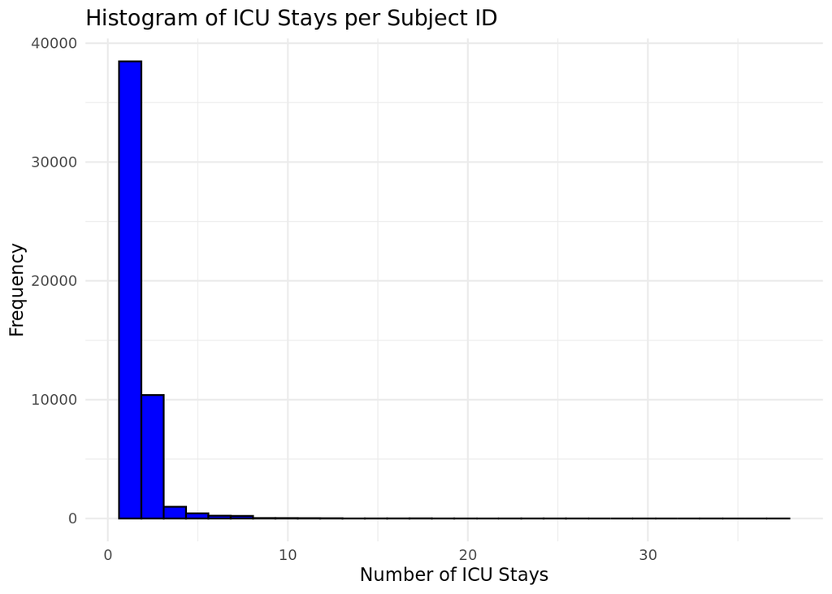

```r
icu_stays_per_subject <- icustays_tble %>%
  group_by(subject_id) %>%
  tally(name = "icu_stays_count")

# Create a histogram summarizing the number of ICU stays per subject_id
ggplot(icu_stays_per_subject, aes(x = icu_stays_count)) +
  geom_histogram(bins = 30, fill = "blue", color = "black") +
  labs(x = "Number of ICU Stays", y = "Frequency",
       title = "Histogram of ICU Stays per Subject ID") +
  theme_minimal()
```

## Q3. `admissions` data

Information of the patients admitted into hospital is available in `admissions.csv.gz`. See https://mimic.mit.edu/docs/iv/modules/hosp/admissions/ for details of each field in this file. The first 10 lines are

```bash
zcat < ~/mimic/hosp/admissions.csv.gz | head
```

```
subject_id,hadm_id,admittime,dischtime,deathtime,admission_type,admit_provider_id,admission_location,discharge_location,insurance,language,marital_status,race,edregtime,edouttime,hospital_expire_flag
10000032,22595853,2180-05-06 22:23:00,2180-05-07 17:15:00,,URGENT,P874LG,TRANSFER FROM HOSPITAL,HOME,Other,ENGLISH,WIDOWED,WHITE,2180-05-06 19:17:00,2180-05-06 23:30:00,0
10000032,22841357,2180-06-26 18:27:00,2180-06-27 18:49:00,,EW EMER.,P09Q6Y,EMERGENCY ROOM,HOME,Medicaid,ENGLISH,WIDOWED,WHITE,2180-06-26 15:54:00,2180-06-26 21:31:00,0
10000032,25742920,2180-08-05 23:44:00,2180-08-07 17:50:00,,EW EMER.,P60CC5,EMERGENCY ROOM,HOSPICE,Medicaid,ENGLISH,WIDOWED,WHITE,2180-08-05 20:58:00,2180-08-06 01:44:00,0
10000032,29079034,2180-07-23 12:35:00,2180-07-25 17:55:00,,EW EMER.,P30KEH,EMERGENCY ROOM,HOME,Medicaid,ENGLISH,WIDOWED,WHITE,2180-07-23 05:54:00,2180-07-23 14:00:00,0
10000068,25022803,2160-03-03 23:16:00,2160-03-04 06:26:00,,EU OBSERVATION,P51VDL,EMERGENCY ROOM,,Other,ENGLISH,SINGLE,WHITE,2160-03-03 21:55:00,2160-03-04 06:26:00,0
10000084,23052089,2160-11-21 01:56:00,2160-11-25 14:52:00,,EW EMER.,P6957U,WALK-IN/SELF REFERRAL,HOME HEALTH CARE,Medicare,ENGLISH,MARRIED,WHITE,2160-11-20 20:36:00,2160-11-21 03:20:00,0
10000084,29888819,2160-12-28 05:11:00,2160-12-28 16:07:00,,EU OBSERVATION,P63AD6,PHYSICIAN REFERRAL,,Medicare,ENGLISH,MARRIED,WHITE,2160-12-27 18:32:00,2160-12-28 16:07:00,0
10000108,27250926,2163-09-27 23:17:00,2163-09-28 09:04:00,,EU OBSERVATION,P38XXV,EMERGENCY ROOM,,Other,ENGLISH,SINGLE,WHITE,2163-09-27 16:18:00,2163-09-28 09:04:00,0
10000117,22927623,2181-11-15 02:05:00,2181-11-15 14:52:00,,EU OBSERVATION,P2358X,EMERGENCY ROOM,,Other,ENGLISH,DIVORCED,WHITE,2181-11-14 21:51:00,2181-11-15 09:57:00,0
```

### Q3.1 Ingestion

Import `admissions.csv.gz` as a tibble `admissions_tble`.

```r
admissions_tble <- read_csv("~/mimic/hosp/admissions.csv.gz") %>%
  as_tibble()
# If you want to check the structure of the imported tibble
print(admissions_tble)
```

```
# A tibble: 431,231 × 16
   subject_id  hadm_id admittime           dischtime
        <dbl>    <dbl> <dttm>              <dttm>
 1   10000032 22595853 2180-05-06 22:23:00 2180-05-07 17:15:00
 2   10000032 22841357 2180-06-26 18:27:00 2180-06-27 18:49:00
 3   10000032 25742920 2180-08-05 23:44:00 2180-08-07 17:50:00
 4   10000032 29079034 2180-07-23 12:35:00 2180-07-25 17:55:00
 5   10000068 25022803 2160-03-03 23:16:00 2160-03-04 06:26:00
 6   10000084 23052089 2160-11-21 01:56:00 2160-11-25 14:52:00
 7   10000084 29888819 2160-12-28 05:11:00 2160-12-28 16:07:00
 8   10000108 27250926 2163-09-27 23:17:00 2163-09-28 09:04:00
 9   10000117 22927623 2181-11-15 02:05:00 2181-11-15 14:52:00
10   10000117 27988844 2183-09-18 18:10:00 2183-09-21 16:30:00
# ℹ 431,221 more rows
# ℹ 12 more variables: deathtime <dttm>, admission_type <chr>,
#   admit_provider_id <chr>, admission_location <chr>,
#   discharge_location <chr>, insurance <chr>, language <chr>,
#   marital_status <chr>, race <chr>, edregtime <dttm>, edouttime <dttm>,
#   hospital_expire_flag <dbl>
```

### Q3.2 Summary and visualization

Summarize the following information by graphics and explain any patterns you see.

- number of admissions per patient
- admission hour (anything unusual?)
- admission minute (anything unusual?)
- length of hospital stay (from admission to discharge) (anything unusual?)

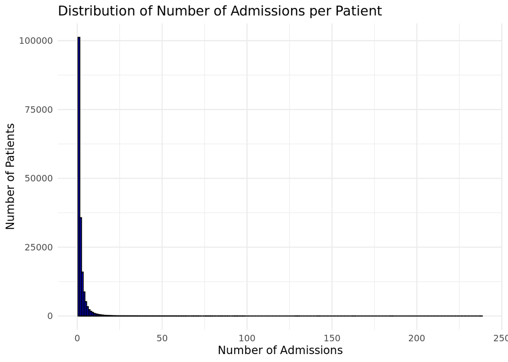

```r
# Summarize the number of admissions per patient
admissions_per_patient <- admissions_tble %>%
  count(subject_id)

# Plot the number of admissions per patient
ggplot(admissions_per_patient, aes(x = n)) +
  geom_histogram(binwidth = 1, fill = "blue", color = "black") +
  labs(x = "Number of Admissions", y = "Number of Patients",
       title = "Distribution of Number of Admissions per Patient") +
  theme_minimal()
```

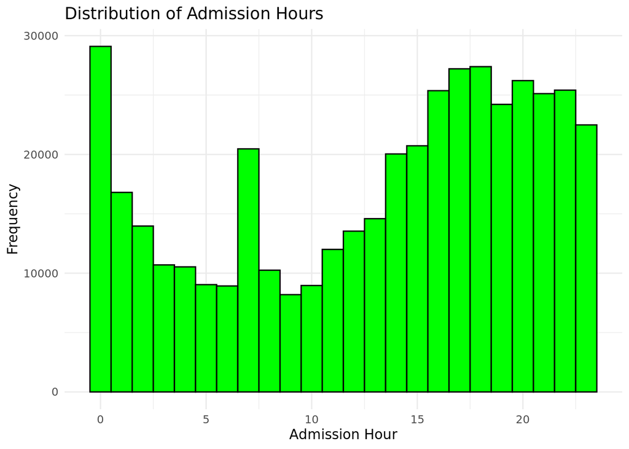

```r
# Extract admission hour and summarize
admissions_tble <- admissions_tble %>%
  mutate(admit_hour = hour(admittime))

# Plot the admission hour
ggplot(admissions_tble, aes(x = admit_hour)) +
  geom_histogram(binwidth = 1, fill = "green", color = "black") +
  labs(x = "Admission Hour", y = "Frequency",
       title = "Distribution of Admission Hours") +
  theme_minimal()
```

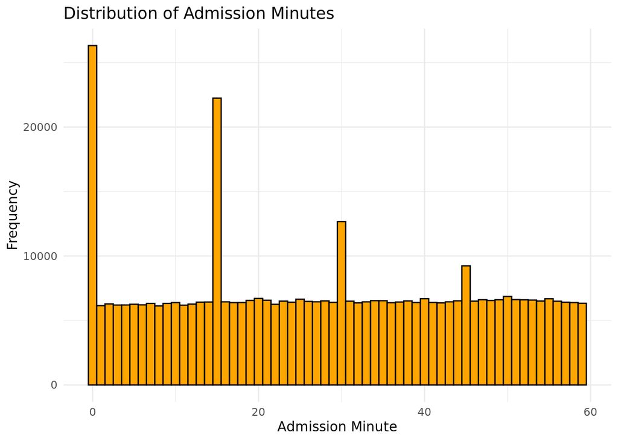

```r
# Extract admission minute and summarize
admissions_tble <- admissions_tble %>%
  mutate(admit_minute = minute(admittime))

# Plot the admission minute
ggplot(admissions_tble, aes(x = admit_minute)) +
  geom_histogram(binwidth = 1, fill = "orange", color = "black") +
  labs(x = "Admission Minute", y = "Frequency",
       title = "Distribution of Admission Minutes") +
  theme_minimal()
```

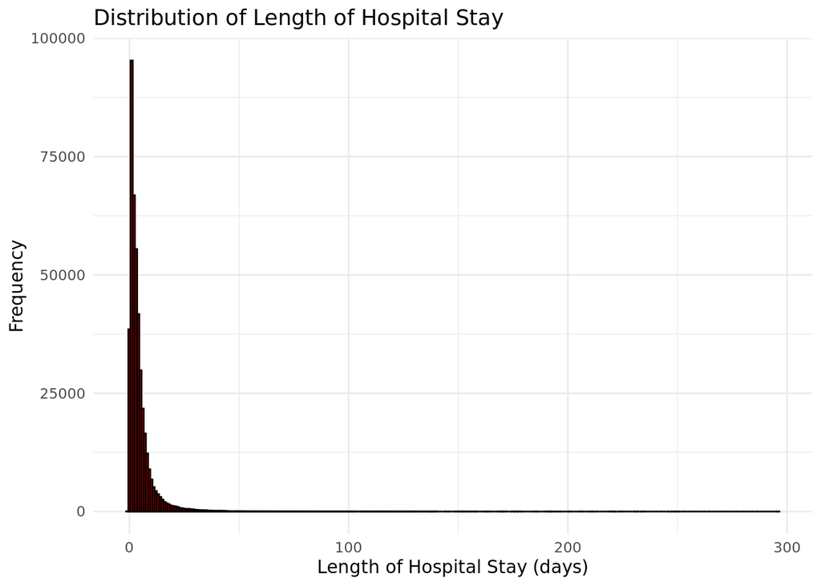

```r
# Calculate length of stay in days
admissions_tble <- admissions_tble %>%
  mutate(length_of_stay = as.numeric(dischtime - admittime, units = "days"))

# Plot the length of stay
ggplot(admissions_tble, aes(x = length_of_stay)) +
  geom_histogram(binwidth = 1, fill = "red", color = "black") +
  labs(x = "Length of Hospital Stay (days)", y = "Frequency",
       title = "Distribution of Length of Hospital Stay") +
  theme_minimal()
```

According to the [MIMIC-IV documentation](https://mimic.mit.edu/docs/iv/about/concepts/#date-shifting),

> All dates in the database have been shifted to protect patient confidentiality. Dates will be internally consistent for the same patient, but randomly distributed in the future. Dates of birth which occur in the present time are not true dates of birth. Furthermore, dates of birth which occur before the year 1900 occur if the patient is older than 89. In these cases, the patient’s age at their first admission has been fixed to 300.

Distribution of Number of Admissions per Patient:

The distribution is highly skewed to the right, with the majority of patients having only a few admissions. This is typical in healthcare data where most patients have only one or a few hospital visits, while a small number of patients (often with chronic or severe conditions) have multiple admissions. There are some extreme cases where patients have been admitted to the hospital many times, but these are rare.

Distribution of Length of Hospital Stay:

This plot shows a right-skewed distribution, which is typical for length-of-stay data. Most patients have short hospital stays, while a smaller number have longer stays. There are very few instances of extremely long hospital stays, which could represent patients with complex, chronic, or severe conditions requiring extended hospitalization. The long tail of the distribution indicates that while most stays are short, the variability in stay length is high, which could be due to the diverse nature of cases treated in a hospital setting. In summary, these patterns reflect common healthcare practices, such as scheduled admissions and the presence of both short-term and long-term patients. The unusual patterns in admission minutes might warrant further investigation to understand the data entry or recording practices at the hospital. The length of stay distribution is expected and demonstrates the variability in patient needs and treatments.

## Q4. `patients` data

Patient information is available in `patients.csv.gz`. See https://mimic.mit.edu/docs/iv/modules/hosp/patients/ for details of each field in this file. The first 10 lines are

```bash
zcat < ~/mimic/hosp/patients.csv.gz | head
```

```
subject_id,gender,anchor_age,anchor_year,anchor_year_group,dod
10000032,F,52,2180,2014 - 2016,2180-09-09
10000048,F,23,2126,2008 - 2010,
10000068,F,19,2160,2008 - 2010,
10000084,M,72,2160,2017 - 2019,2161-02-13
10000102,F,27,2136,2008 - 2010,
10000108,M,25,2163,2014 - 2016,
10000115,M,24,2154,2017 - 2019,
10000117,F,48,2174,2008 - 2010,
10000178,F,59,2157,2017 - 2019,
```

### Q4.1 Ingestion

Import `patients.csv.gz` (https://mimic.mit.edu/docs/iv/modules/hosp/patients/) as a tibble `patients_tble`.

```r
patients_tble <- read_csv("~/mimic/hosp/patients.csv.gz") %>%
                 as_tibble()
```

### Q4.2 Summary and visualization

Summarize variables `gender` and `anchor_age` by graphics, and explain any patterns you see.

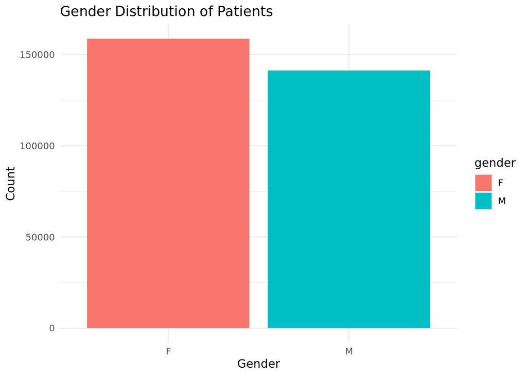

```r
# Summarize gender distribution
gender_distribution <- patients_tble %>%
  count(gender)

# Plot the gender distribution
ggplot(gender_distribution, aes(x = gender, y = n, fill = gender)) +
  geom_bar(stat = "identity") +
  labs(x = "Gender", y = "Count", title = "Gender Distribution of Patients") +
  theme_minimal()
```

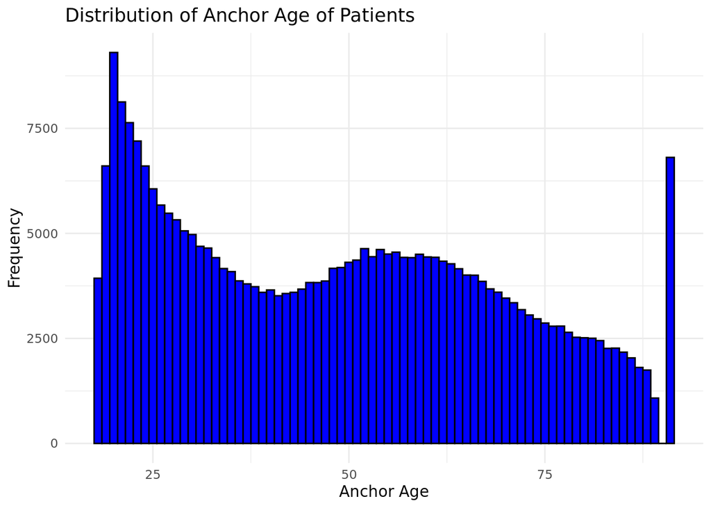

```r
# Plot the distribution of anchor_age
ggplot(patients_tble, aes(x = anchor_age)) +
  geom_histogram(binwidth = 1, fill = "blue", color = "black") +
  labs(x = "Anchor Age", y = "Frequency",
       title = "Distribution of Anchor Age of Patients") +
  theme_minimal()
```

Gender Distribution of Patients:

The bar chart shows the count of patients by gender with a relatively balanced distribution between female (F) and male (M) patients. There does not appear to be a significant skew towards one gender, suggesting that the patient population in this dataset is relatively gender-balanced. This balance could indicate that the hospital serves a general population without a strong gender bias towards diseases or that the dataset is a comprehensive representation of the general patient population.

## Q5. Lab results

`labevents.csv.gz` (https://mimic.mit.edu/docs/iv/modules/hosp/labevents/) contains all laboratory measurements for patients. The first 10 lines are

```bash
zcat < ~/mimic/hosp/labevents.csv.gz | head
```

```
labevent_id,subject_id,hadm_id,specimen_id,itemid,order_provider_id,charttime,storetime,value,valuenum,valueuom,ref_range_lower,ref_range_upper,flag,priority,comments
1,10000032,,45421181,51237,P28Z0X,2180-03-23 11:51:00,2180-03-23 15:15:00,1.4,1.4,,0.9,1.1,abnormal,ROUTINE,
2,10000032,,45421181,51274,P28Z0X,2180-03-23 11:51:00,2180-03-23 15:15:00,___,15.1,sec,9.4,12.5,abnormal,ROUTINE,VERIFIED.
3,10000032,,52958335,50853,P28Z0X,2180-03-23 11:51:00,2180-03-25 11:06:00,___,15,ng/mL,30,60,abnormal,ROUTINE,NEW ASSAY IN USE ___: DETECTS D2 AND D3 25-OH ACCURATELY.
4,10000032,,52958335,50861,P28Z0X,2180-03-23 11:51:00,2180-03-23 16:40:00,102,102,IU/L,0,40,abnormal,ROUTINE,
5,10000032,,52958335,50862,P28Z0X,2180-03-23 11:51:00,2180-03-23 16:40:00,3.3,3.3,g/dL,3.5,5.2,abnormal,ROUTINE,
6,10000032,,52958335,50863,P28Z0X,2180-03-23 11:51:00,2180-03-23 16:40:00,109,109,IU/L,35,105,abnormal,ROUTINE,
7,10000032,,52958335,50864,P28Z0X,2180-03-23 11:51:00,2180-03-23 16:40:00,___,8,ng/mL,0,8.7,,ROUTINE,MEASURED BY ___.
8,10000032,,52958335,50868,P28Z0X,2180-03-23 11:51:00,2180-03-23 16:40:00,12,12,mEq/L,8,20,,ROUTINE,
9,10000032,,52958335,50878,P28Z0X,2180-03-23 11:51:00,2180-03-23 16:40:00,143,143,IU/L,0,40,abnormal,ROUTINE,
```

`d_labitems.csv.gz` (https://mimic.mit.edu/docs/iv/modules/hosp/d_labitems/) is the dictionary of lab measurements.

```bash
zcat < ~/mimic/hosp/d_labitems.csv.gz | head
```

```
itemid,label,fluid,category
50801,Alveolar-arterial Gradient,Blood,Blood Gas
50802,Base Excess,Blood,Blood Gas
50803,"Calculated Bicarbonate, Whole Blood",Blood,Blood Gas
50804,Calculated Total CO2,Blood,Blood Gas
50805,Carboxyhemoglobin,Blood,Blood Gas
50806,"Chloride, Whole Blood",Blood,Blood Gas
50808,Free Calcium,Blood,Blood Gas
50809,Glucose,Blood,Blood Gas
50810,"Hematocrit, Calculated",Blood,Blood Gas
```

We are interested in the lab measurements of creatinine (50912), potassium (50971), sodium (50983), chloride (50902), bicarbonate (50882), hematocrit (51221), white blood cell count (51301), and glucose (50931). Retrieve a subset of `labevents.csv.gz` that only containing these items for the patients in `icustays_tble`. Further restrict to the last available measurement (by `storetime`) before the ICU stay. The final `labevents_tble` should have one row per ICU stay and columns for each lab measurement.

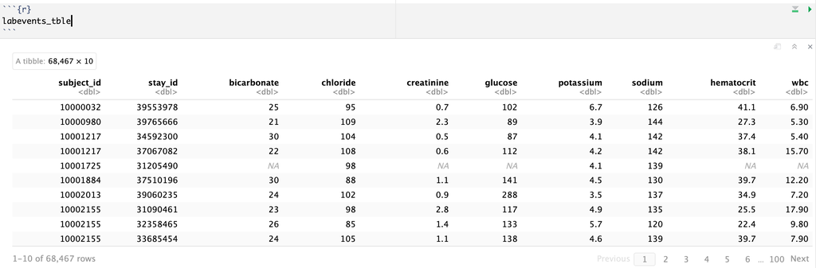

```r
relevant_itemids <- c(50912, 50971, 50983, 50902, 50882, 51221, 51301, 50931)

labe <- arrow::open_dataset(parquet_file_lab) %>%
  select(subject_id,itemid,valuenum,storetime)%>%
  filter( itemid%in% relevant_itemids ) %>%
  collect() # Use collect() to bring the filtered data into memory as a dataframe
```

```r
icustays_tble<- read_csv("~/mimic/icu/icustays.csv.gz")
```

```r
icu_earliest <-  icustays_tble%>%
  group_by(subject_id) %>%
  arrange(subject_id, intime) %>%
  slice_min(order_by = intime, n = 1)%>%
  select(subject_id,stay_id,intime)
```

```r
joinedicu<-right_join(labe, icu_earliest, by = "subject_id")
joinedicu <- joinedicu %>%
  filter(storetime < intime)
```

```r
joinedicu<-group_by(joinedicu,storetime)

joinedicu <- joinedicu %>%
  group_by(stay_id,itemid) %>%
  filter(storetime == max(storetime))
```

```r
labevents_tble <- joinedicu %>%
  ungroup() %>%  # It's important to ungroup before pivoting
  pivot_wider(
    names_from = itemid,
    values_from = valuenum,
    values_fn = list(valuenum = mean),  # Calculate mean in case of duplicates
    id_cols = c(subject_id, stay_id)
  )
```

```r
labevents_tble <- labevents_tble %>%
  rename(
    glucose = `50931`,
    bicarbonate = `50882`,
    chloride = `50902`,
    creatinine = `50912`,
    potassium = `50971`,
    sodium = `50983`,
    hematocrit = `51221`,
    wbc = `51301`
  )
```

```r
  labevents_tble <- labevents_tble %>%
  arrange(subject_id)
labevents_tble
```

```
# A tibble: 46,227 × 10
   subject_id  stay_id hematocrit   wbc bicarbonate chloride creatinine glucose
        <dbl>    <dbl>      <dbl> <dbl>       <dbl>    <dbl>      <dbl>   <dbl>
 1   10000032 39553978       41.1   6.9          25       95        0.7     102
 2   10000980 39765666       27.3   5.3          21      109        2.3      89
 3   10001217 37067082       38.1  15.7          22      108        0.6     112
 4   10001725 31205490       NA    NA            NA       98       NA        NA
 5   10001884 37510196       39.7  12.2          30       88        1.1     141
 6   10002013 39060235       34.9   7.2          24      102        0.9     288
 7   10002155 33685454       39.7   7.9          24      105        1.1     138
 8   10002348 32610785       36.3   7.3          22      106        0.8      82
 9   10002428 33987268       36.1  20.2          25       89        1.1     121
10   10002430 38392119       29.9   5.1          23      102        1.9     105
# ℹ 46,217 more rows
# ℹ 2 more variables: potassium <dbl>, sodium <dbl>
```

Hint: Use the Parquet format you generated in Homework 2. For reproducibility, make `labevents_pq` folder available at the current working directory `hw3`, for example, by a symbolic link.

## Q6. Vitals from charted events

`chartevents.csv.gz` (https://mimic.mit.edu/docs/iv/modules/icu/chartevents/) contains all the charted data available for a patient. During their ICU stay, the primary repository of a patient’s information is their electronic chart. The `itemid` variable indicates a single measurement type in the database. The `value` variable is the value measured for `itemid`. The first 10 lines of `chartevents.csv.gz` are

```bash
zcat < ~/mimic/icu/chartevents.csv.gz | head
```

```
subject_id,hadm_id,stay_id,caregiver_id,charttime,storetime,itemid,value,valuenum,valueuom,warning
10000032,29079034,39553978,47007,2180-07-23 21:01:00,2180-07-23 22:15:00,220179,82,82,mmHg,0
10000032,29079034,39553978,47007,2180-07-23 21:01:00,2180-07-23 22:15:00,220180,59,59,mmHg,0
10000032,29079034,39553978,47007,2180-07-23 21:01:00,2180-07-23 22:15:00,220181,63,63,mmHg,0
10000032,29079034,39553978,47007,2180-07-23 22:00:00,2180-07-23 22:15:00,220045,94,94,bpm,0
10000032,29079034,39553978,47007,2180-07-23 22:00:00,2180-07-23 22:15:00,220179,85,85,mmHg,0
10000032,29079034,39553978,47007,2180-07-23 22:00:00,2180-07-23 22:15:00,220180,55,55,mmHg,0
10000032,29079034,39553978,47007,2180-07-23 22:00:00,2180-07-23 22:15:00,220181,62,62,mmHg,0
10000032,29079034,39553978,47007,2180-07-23 22:00:00,2180-07-23 22:15:00,220210,20,20,insp/min,0
10000032,29079034,39553978,47007,2180-07-23 22:00:00,2180-07-23 22:15:00,220277,95,95,%,0
```

`d_items.csv.gz` (https://mimic.mit.edu/docs/iv/modules/icu/d_items/) is the dictionary for the `itemid` in `chartevents.csv.gz`.

```bash
zcat < ~/mimic/icu/d_items.csv.gz | head
```

```
itemid,label,abbreviation,linksto,category,unitname,param_type,lownormalvalue,highnormalvalue
220001,Problem List,Problem List,chartevents,General,,Text,,
220003,ICU Admission date,ICU Admission date,datetimeevents,ADT,,Date and time,,
220045,Heart Rate,HR,chartevents,Routine Vital Signs,bpm,Numeric,,
220046,Heart rate Alarm - High,HR Alarm - High,chartevents,Alarms,bpm,Numeric,,
220047,Heart Rate Alarm - Low,HR Alarm - Low,chartevents,Alarms,bpm,Numeric,,
220048,Heart Rhythm,Heart Rhythm,chartevents,Routine Vital Signs,,Text,,
220050,Arterial Blood Pressure systolic,ABPs,chartevents,Routine Vital Signs,mmHg,Numeric,90,140
220051,Arterial Blood Pressure diastolic,ABPd,chartevents,Routine Vital Signs,mmHg,Numeric,60,90
220052,Arterial Blood Pressure mean,ABPm,chartevents,Routine Vital Signs,mmHg,Numeric,,
```

We are interested in the vitals for ICU patients: heart rate (220045), systolic non-invasive blood pressure (220179), diastolic non-invasive blood pressure (220180), body temperature in Fahrenheit (223761), and respiratory rate (220210). Retrieve a subset of `chartevents.csv.gz` only containing these items for the patients in `icustays_tble`. Further restrict to the first vital measurement within the ICU stay. The final `chartevents_tble` should have one row per ICU stay and columns for each vital measurement.

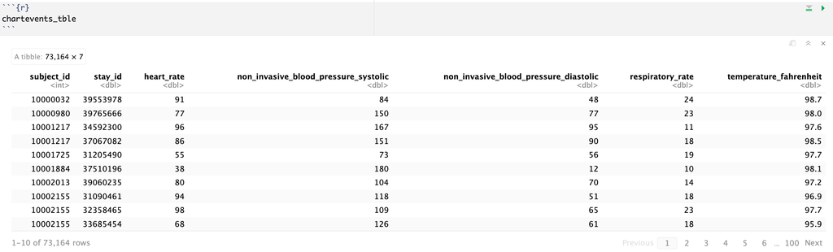

```r
rm(list = ls())
csv_file_chart <- "~/mimic/icu/chartevents.csv"
parquet_file_chart <- "./chartevents.parquet"

# Read the CSV file
chartevents_dataset <- arrow::open_dataset(csv_file_chart, format = "csv")

# Write the dataset to a Parquet file
arrow::write_dataset(chartevents_dataset, parquet_file_chart, format = "parquet")
```

```r
icustays_tble<- read_csv("~/mimic/icu/icustays.csv.gz") %>%
  select(subject_id,stay_id,intime,outtime)

chartevents_d_tble<-read_csv("~/mimic/icu/d_items.csv.gz") %>%
  select(itemid, label)
```

```r
library(arrow)
chartevents_tble <- open_dataset(parquet_file_chart, format = "parquet") %>%
  filter(itemid %in% c(220045, 220179, 220180, 223761, 220210)) %>%
  select(subject_id,hadm_id,stay_id,storetime,itemid,valuenum)

chartevents_tble <- as_tibble(chartevents_tble)

icustays_tble<- read_csv("~/mimic/icu/icustays.csv.gz") %>%
  select(subject_id,stay_id,intime,outtime)

chartevents_d_tble<-read_csv("~/mimic/icu/d_items.csv.gz") %>%
  select(itemid, label)
```

```r
vi<-c(220045,220179,220180,223761,220210)

# Filter the data for subject_id 10013310 without loading everything into memory
vichev <- arrow::open_dataset(parquet_file_chart) %>%
  filter(itemid %in% vi ) %>%
  select(subject_id,hadm_id,stay_id,storetime,itemid,valuenum)%>%
collect()

 # Use collect() to bring the filtered data into memory as a dataframe

# `filtered_data` now contains all the rows for subject_id 10013310
```

```r
icustays_tble <- icustays_tble %>% select(subject_id, intime, outtime, stay_id)
```

```r
filtered_vichev <- icustays_tble %>%
  inner_join(vichev, by = "subject_id") %>%
  filter(intime <= storetime & outtime >= storetime) %>%
  select(subject_id, itemid, storetime, intime, outtime, stay_id, valuenum)
```

```r
earliest_itemid_per_stay <- filtered_vichev %>%
  group_by(stay_id, itemid) %>%
  arrange(storetime) %>%
  slice(1) %>%
  ungroup()
```

```r
library("data.table")
setDT(vichev) # Convert 'vichev' to data.table
setDT(icustays_tble) # Conv
```

```r
filtered_vichev <- icustays_tble[vichev,
                                .(subject_id, itemid, storetime, intime, outtime,stay_id,valuenum),
                                on = .(subject_id = subject_id, intime <= storetime, outtime >= storetime),
                                nomatch = 0] # Ensures we only include matches
filtered_vichev
```

```r
earliest_itemid_per_stay <- filtered_vichev[, .SD[order(storetime)][1], by = .(stay_id, itemid)]
```

```r
wide_format <- earliest_itemid_per_stay %>%
  pivot_wider(names_from = itemid, values_from = valuenum, id_cols = c(subject_id, stay_id))
```

```r
chartevents_tble <- wide_format %>%
  rename(
    heart_rate = `220045`,
    non_invasive_blood_pressure_systolic = `220179`,
    non_invasive_blood_pressure_diastolic = `220180`,
    respiratory_rate = `220210`,
    temperature_fahrenheit = `223761`
  ) %>%
arrange(subject_id)
chartevents_tble
```

[output not shown]

Hint: Use the Parquet format you generated in Homework 2. For reproducibility, make `chartevents_pq` folder available at the current working directory, for example, by a symbolic link.

## Q7. Putting things together

Let us create a tibble `mimic_icu_cohort` for all ICU stays, where rows are all ICU stays of adults (age at `intime` >= 18) and columns contain at least following variables

- all variables in `icustays_tble`
- all variables in `admissions_tble`
- all variables in `patients_tble`
- the last lab measurements before the ICU stay in `labevents_tble`
- the first vital measurements during the ICU stay in `chartevents_tble`

The final `mimic_icu_cohort` should have one row per ICU stay and columns for each variable.

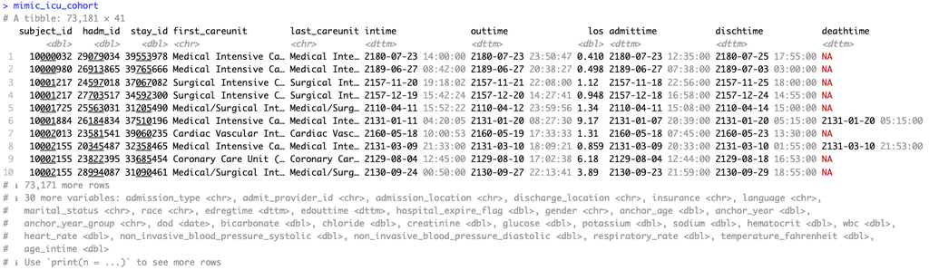

```r
# # TODO
 mimic_icu_cohort <- icustays_tble%>%
  left_join(admissions,by=c("subject_id","hadm_id"))%>%
  left_join(patients,by="subject_id")%>%
  mutate(age_intime=year(intime)-anchor_year + anchor_age)%>%
  filter(age_intime>=18)%>%
  left_join(labevents_tble, by= c("subject_id","stay_id"))%>%
  left_join(chartevents_tble, by = c("subject_id", "stay_id"))
```

## Q8. Exploratory data analysis (EDA)

```r
mimiciv_icu_cohort<-readRDS("../hw4/mimiciv_shiny/mimic_icu_cohort.rds")
```

Summarize the following information about the ICU stay cohort `mimic_icu_cohort` using appropriate numerics or graphs:

- Length of ICU stay `los` vs demographic variables (race, insurance, marital_status, gender, age at intime)

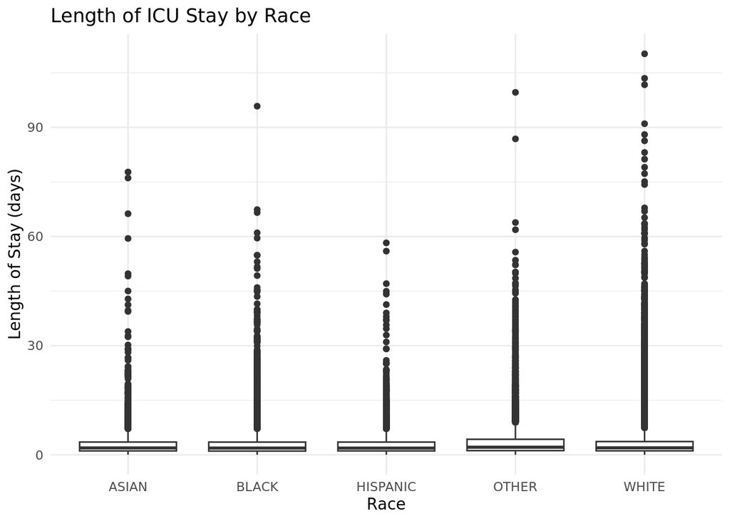

```r
library(ggplot2)

# Assuming your data frame is named mimic_icu_cohort and it has the columns los and race
ggplot(mimiciv_icu_cohort, aes(x=race, y=los)) +
  geom_boxplot() +
  labs(title="Length of ICU Stay by Race",
       x="Race",
       y="Length of Stay (days)") +
  theme_minimal()
```

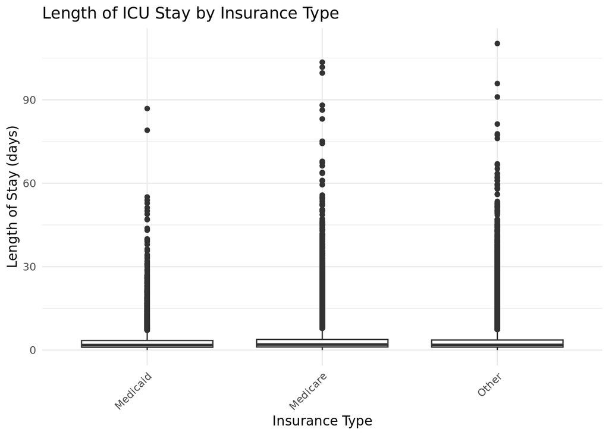

```r
library(ggplot2)

# Assuming your data frame is named mimic_icu_cohort and it has the columns los and insurance
ggplot(mimiciv_icu_cohort, aes(x=insurance, y=los)) +
  geom_boxplot() +
  labs(title="Length of ICU Stay by Insurance Type",
       x="Insurance Type",
       y="Length of Stay (days)") +
  theme_minimal() +
  theme(axis.text.x = element_text(angle = 45, hjust = 1)) # This rotates the x-axis labels for better readability
```

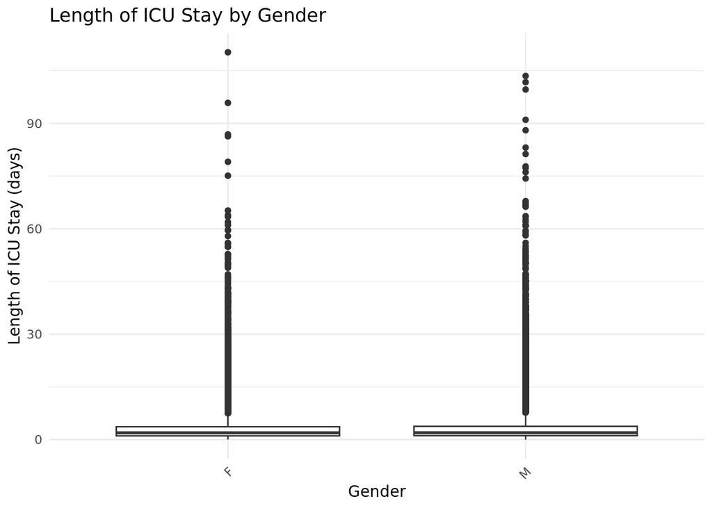

```r
library(ggplot2)

# Replace 'mimic_icu_cohort' with the actual name of your data frame, and ensure 'los' and 'gender' are the correct column names
ggplot(data = mimiciv_icu_cohort, aes(x = gender, y = los)) +
  geom_boxplot() +
  labs(title = "Length of ICU Stay by Gender", x = "Gender", y = "Length of ICU Stay (days)") +
  theme_minimal() +
  theme(axis.text.x = element_text(angle = 45, hjust = 1))  # Adjust text angle if necessary for readability
```

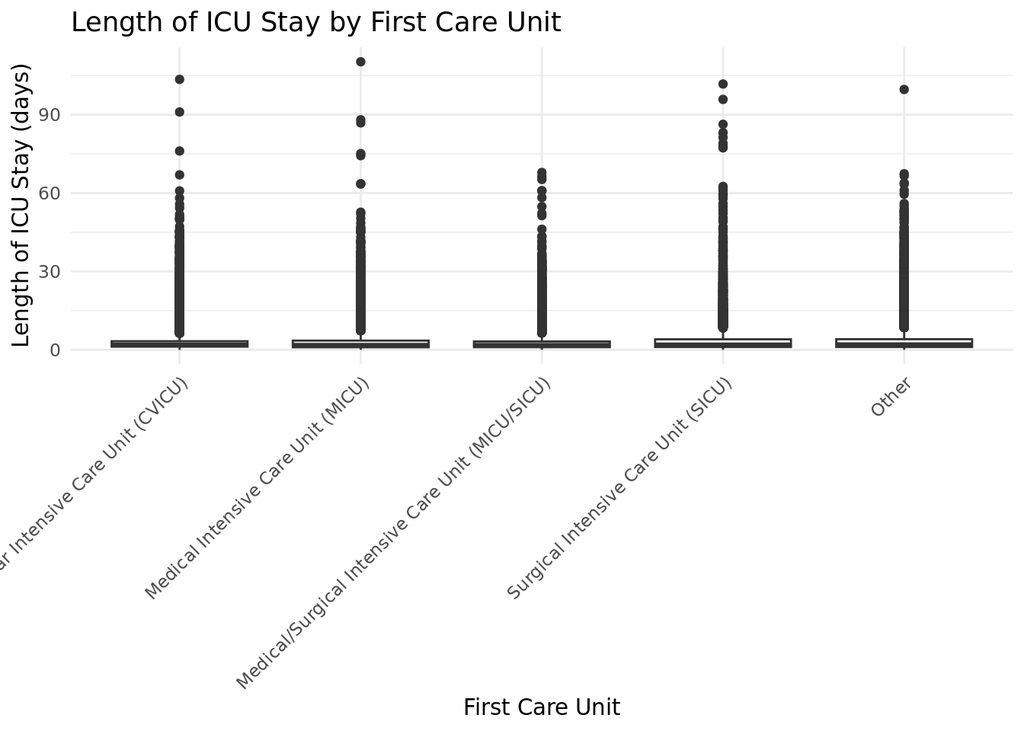

```r
library(ggplot2)

# Assuming your data frame is named mimic_icu_cohort and it has the columns los and first_careunit
ggplot(data = mimiciv_icu_cohort, aes(x = first_careunit, y = los)) +
  geom_boxplot() +
  labs(title = "Length of ICU Stay by First Care Unit", x = "First Care Unit", y = "Length of ICU Stay (days)") +
  theme_minimal() +
  theme(axis.text.x = element_text(angle = 45, hjust = 1))  # Rotate x-axis text labels if there are many categories
```

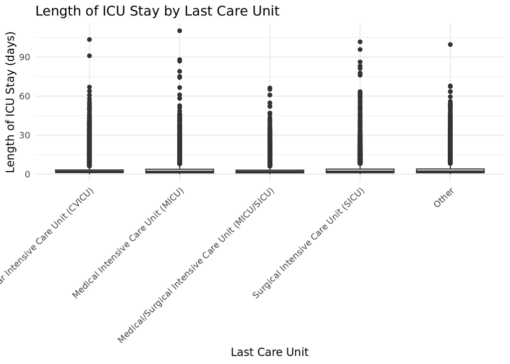

```r
library(ggplot2)

# Assuming your data frame is named mimic_icu_cohort and has the columns los and last_careunit
ggplot(data = mimiciv_icu_cohort, aes(x = last_careunit, y = los)) +
  geom_boxplot() +
  labs(title = "Length of ICU Stay by Last Care Unit", x = "Last Care Unit", y = "Length of ICU Stay (days)") +
  theme_minimal() +
  theme(axis.text.x = element_text(angle = 45, hjust = 1))  # This will rotate the x-axis labels for clarity
```

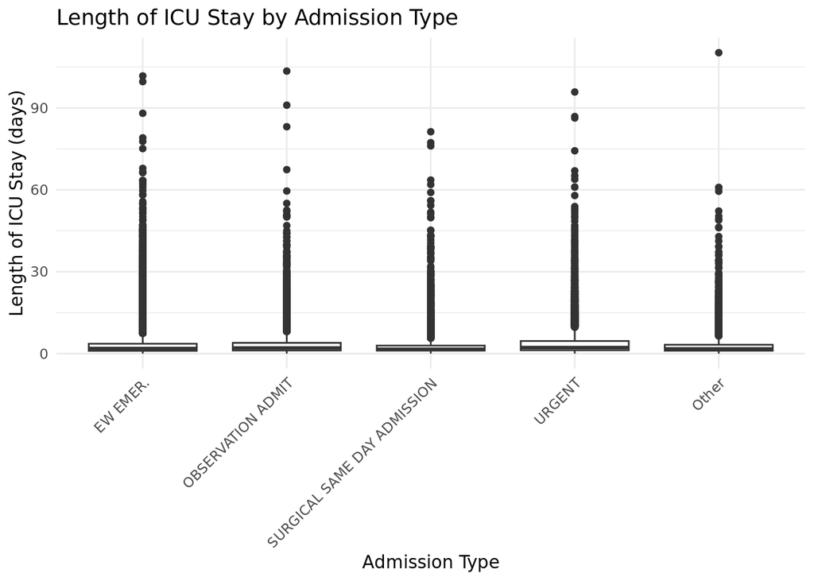

```r
library(ggplot2)

# Assuming your data frame is named mimic_icu_cohort and it has the columns los and admission_type
ggplot(data = mimiciv_icu_cohort, aes(x = admission_type, y = los)) +
  geom_boxplot() +
  labs(title = "Length of ICU Stay by Admission Type",
       x = "Admission Type",
       y = "Length of ICU Stay (days)") +
  theme_minimal() +
  theme(axis.text.x = element_text(angle = 45, hjust = 1)) # This will help if labels are long and need to be read at an angle.
```